# Risk Factor Analysis

## Outcome Variable

**Outcome Variable:** haz

## Predictor Variables

**Intervention Variable:** pers_wast

**Adjustment Set:**

- arm
- sex
- brthmon
- W_mage
- meducyrs
- hhwealth_quart
- W_nrooms
- month
- W_parity
- delta_W_mage
- delta_meducyrs
- delta_hhwealth_quart
- delta_W_nrooms
- delta_month
- delta_W_parity

## Stratifying Variables

The analysis was stratified on these variable(s):

- agecat
- studyid
- country

## Data Summary

| agecat | studyid | country | pers_wast | n_cell | n | outcome_variable |
| --- | --- | --- | --- | --- | --- | --- |
| Birth | ki0047075b-MAL-ED | BANGLADESH | 0 | 220 | 229 | haz |
| Birth | ki0047075b-MAL-ED | BANGLADESH | 1 | 9 | 229 | haz |
| Birth | ki0047075b-MAL-ED | BRAZIL | 0 | 65 | 65 | haz |
| Birth | ki0047075b-MAL-ED | BRAZIL | 1 | 0 | 65 | haz |
| Birth | ki0047075b-MAL-ED | INDIA | 0 | 43 | 45 | haz |
| Birth | ki0047075b-MAL-ED | INDIA | 1 | 2 | 45 | haz |
| Birth | ki0047075b-MAL-ED | NEPAL | 0 | 26 | 27 | haz |
| Birth | ki0047075b-MAL-ED | NEPAL | 1 | 1 | 27 | haz |
| Birth | ki0047075b-MAL-ED | PERU | 0 | 233 | 233 | haz |
| Birth | ki0047075b-MAL-ED | PERU | 1 | 0 | 233 | haz |
| Birth | ki0047075b-MAL-ED | SOUTH AFRICA | 0 | 111 | 113 | haz |
| Birth | ki0047075b-MAL-ED | SOUTH AFRICA | 1 | 2 | 113 | haz |
| Birth | ki0047075b-MAL-ED | TANZANIA, UNITED REPUBLIC OF | 0 | 123 | 123 | haz |
| Birth | ki0047075b-MAL-ED | TANZANIA, UNITED REPUBLIC OF | 1 | 0 | 123 | haz |
| Birth | ki1000108-CMC-V-BCS-2002 | INDIA | 0 | 80 | 92 | haz |
| Birth | ki1000108-CMC-V-BCS-2002 | INDIA | 1 | 12 | 92 | haz |
| Birth | ki1000108-IRC | INDIA | 0 | 319 | 387 | haz |
| Birth | ki1000108-IRC | INDIA | 1 | 68 | 387 | haz |
| Birth | ki1000109-EE | PAKISTAN | 0 | 224 | 240 | haz |
| Birth | ki1000109-EE | PAKISTAN | 1 | 16 | 240 | haz |
| Birth | ki1000109-ResPak | PAKISTAN | 0 | 30 | 34 | haz |
| Birth | ki1000109-ResPak | PAKISTAN | 1 | 4 | 34 | haz |
| Birth | ki1017093b-PROVIDE | BANGLADESH | 0 | 516 | 539 | haz |
| Birth | ki1017093b-PROVIDE | BANGLADESH | 1 | 23 | 539 | haz |
| Birth | ki1101329-Keneba | GAMBIA | 0 | 1374 | 1419 | haz |
| Birth | ki1101329-Keneba | GAMBIA | 1 | 45 | 1419 | haz |
| Birth | ki1113344-GMS-Nepal | NEPAL | 0 | 521 | 585 | haz |
| Birth | ki1113344-GMS-Nepal | NEPAL | 1 | 64 | 585 | haz |
| Birth | ki1114097-CMIN | BANGLADESH | 0 | 16 | 18 | haz |
| Birth | ki1114097-CMIN | BANGLADESH | 1 | 2 | 18 | haz |

[output cut: 70 more lines]

The following strata were considered:

- agecat: 24 months, studyid: ki0047075b-MAL-ED, country: BANGLADESH
- agecat: 24 months, studyid: ki0047075b-MAL-ED, country: BRAZIL
- agecat: 24 months, studyid: ki0047075b-MAL-ED, country: INDIA
- agecat: 24 months, studyid: ki0047075b-MAL-ED, country: NEPAL
- agecat: 24 months, studyid: ki0047075b-MAL-ED, country: PERU
- agecat: 24 months, studyid: ki0047075b-MAL-ED, country: SOUTH AFRICA
- agecat: 24 months, studyid: ki0047075b-MAL-ED, country: TANZANIA, UNITED REPUBLIC OF
- agecat: 24 months, studyid: ki1000108-CMC-V-BCS-2002, country: INDIA
- agecat: 24 months, studyid: ki1000108-IRC, country: INDIA
- agecat: 24 months, studyid: ki1000109-EE, country: PAKISTAN
- agecat: 24 months, studyid: ki1017093b-PROVIDE, country: BANGLADESH
- agecat: 24 months, studyid: ki1066203-TanzaniaChild2, country: TANZANIA, UNITED REPUBLIC OF
- agecat: 24 months, studyid: ki1101329-Keneba, country: GAMBIA
- agecat: 24 months, studyid: ki1113344-GMS-Nepal, country: NEPAL
- agecat: 24 months, studyid: ki1114097-CMIN, country: BANGLADESH
- agecat: 24 months, studyid: ki1114097-CONTENT, country: PERU
- agecat: 6 months, studyid: ki0047075b-MAL-ED, country: BANGLADESH
- agecat: 6 months, studyid: ki0047075b-MAL-ED, country: BRAZIL
- agecat: 6 months, studyid: ki0047075b-MAL-ED, country: INDIA
- agecat: 6 months, studyid: ki0047075b-MAL-ED, country: NEPAL
- agecat: 6 months, studyid: ki0047075b-MAL-ED, country: PERU
- agecat: 6 months, studyid: ki0047075b-MAL-ED, country: SOUTH AFRICA
- agecat: 6 months, studyid: ki0047075b-MAL-ED, country: TANZANIA, UNITED REPUBLIC OF
- agecat: 6 months, studyid: ki1000108-CMC-V-BCS-2002, country: INDIA
- agecat: 6 months, studyid: ki1000108-IRC, country: INDIA
- agecat: 6 months, studyid: ki1000109-EE, country: PAKISTAN
- agecat: 6 months, studyid: ki1000109-ResPak, country: PAKISTAN
- agecat: 6 months, studyid: ki1017093b-PROVIDE, country: BANGLADESH
- agecat: 6 months, studyid: ki1066203-TanzaniaChild2, country: TANZANIA, UNITED REPUBLIC OF
- agecat: 6 months, studyid: ki1101329-Keneba, country: GAMBIA
- agecat: 6 months, studyid: ki1112895-Guatemala BSC, country: GUATEMALA
- agecat: 6 months, studyid: ki1113344-GMS-Nepal, country: NEPAL
- agecat: 6 months, studyid: ki1114097-CMIN, country: BANGLADESH
- agecat: 6 months, studyid: ki1114097-CONTENT, country: PERU
- agecat: Birth, studyid: ki0047075b-MAL-ED, country: BANGLADESH
- agecat: Birth, studyid: ki0047075b-MAL-ED, country: BRAZIL
- agecat: Birth, studyid: ki0047075b-MAL-ED, country: INDIA
- agecat: Birth, studyid: ki0047075b-MAL-ED, country: NEPAL
- agecat: Birth, studyid: ki0047075b-MAL-ED, country: PERU
- agecat: Birth, studyid: ki0047075b-MAL-ED, country: SOUTH AFRICA
- agecat: Birth, studyid: ki0047075b-MAL-ED, country: TANZANIA, UNITED REPUBLIC OF
- agecat: Birth, studyid: ki1000108-CMC-V-BCS-2002, country: INDIA
- agecat: Birth, studyid: ki1000108-IRC, country: INDIA
- agecat: Birth, studyid: ki1000109-EE, country: PAKISTAN
- agecat: Birth, studyid: ki1000109-ResPak, country: PAKISTAN
- agecat: Birth, studyid: ki1017093b-PROVIDE, country: BANGLADESH
- agecat: Birth, studyid: ki1101329-Keneba, country: GAMBIA
- agecat: Birth, studyid: ki1113344-GMS-Nepal, country: NEPAL
- agecat: Birth, studyid: ki1114097-CMIN, country: BANGLADESH
- agecat: Birth, studyid: ki1114097-CONTENT, country: PERU

### Dropped Strata

Some strata were dropped due to rare outcomes:

- agecat: Birth, studyid: ki0047075b-MAL-ED, country: BRAZIL
- agecat: Birth, studyid: ki0047075b-MAL-ED, country: INDIA
- agecat: Birth, studyid: ki0047075b-MAL-ED, country: NEPAL
- agecat: Birth, studyid: ki0047075b-MAL-ED, country: PERU
- agecat: Birth, studyid: ki0047075b-MAL-ED, country: SOUTH AFRICA
- agecat: Birth, studyid: ki0047075b-MAL-ED, country: TANZANIA, UNITED REPUBLIC OF
- agecat: Birth, studyid: ki1000109-ResPak, country: PAKISTAN
- agecat: Birth, studyid: ki1114097-CMIN, country: BANGLADESH
- agecat: Birth, studyid: ki1114097-CONTENT, country: PERU
- agecat: 6 months, studyid: ki0047075b-MAL-ED, country: BRAZIL
- agecat: 6 months, studyid: ki0047075b-MAL-ED, country: PERU
- agecat: 6 months, studyid: ki0047075b-MAL-ED, country: SOUTH AFRICA
- agecat: 6 months, studyid: ki0047075b-MAL-ED, country: TANZANIA, UNITED REPUBLIC OF
- agecat: 6 months, studyid: ki1114097-CONTENT, country: PERU
- agecat: 24 months, studyid: ki0047075b-MAL-ED, country: BRAZIL
- agecat: 24 months, studyid: ki0047075b-MAL-ED, country: PERU
- agecat: 24 months, studyid: ki0047075b-MAL-ED, country: SOUTH AFRICA
- agecat: 24 months, studyid: ki0047075b-MAL-ED, country: TANZANIA, UNITED REPUBLIC OF
- agecat: 24 months, studyid: ki1066203-TanzaniaChild2, country: TANZANIA, UNITED REPUBLIC OF
- agecat: 24 months, studyid: ki1114097-CONTENT, country: PERU

## Methods Detail

We’re interested in the causal parameters $E[Y_a]$ for all values of $a \in \mathcal{A}$. These parameters represent the mean outcome if, possibly contrary to fact, we intervened to set all units to have $A=a$. Under the randomization and positivity assumptions, these are identified by the statistical parameters $\psi_a=E_W[E_{Y|A,W}(Y|A=a,W)]$. In addition, we’re interested in the mean of $Y$, $E[Y]$ under no intervention (the observed mean). We will estimate these parameters by using SuperLearner to fit the relevant likelihood factors – $E_{Y|A,W}(Y|A=a,W)$ and $p(A=a|W)$, and then updating our likelihood fit using a joint TMLE.

For unadjusted analyses ($W=\{\}$), initial likelihoods were estimated using Lrnr_glm to estimate the simple $E(Y|A)$ and Lrnr_mean to estimate $p(A)$. For adjusted analyses, a small library containing Lrnr_glmnet, Lrnr_xgboost, and Lrnr_mean was used.

Having estimated these parameters, we will then use the delta method to estimate relative risks and attributable risks relative to a prespecified baseline level of $A$.

# Results Detail

## Results Plots

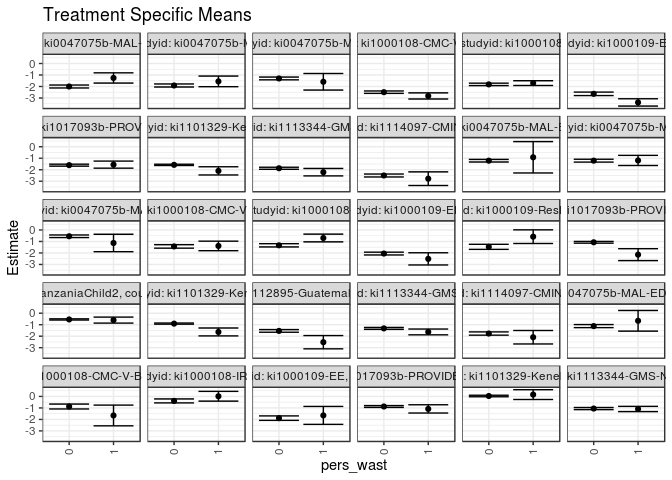

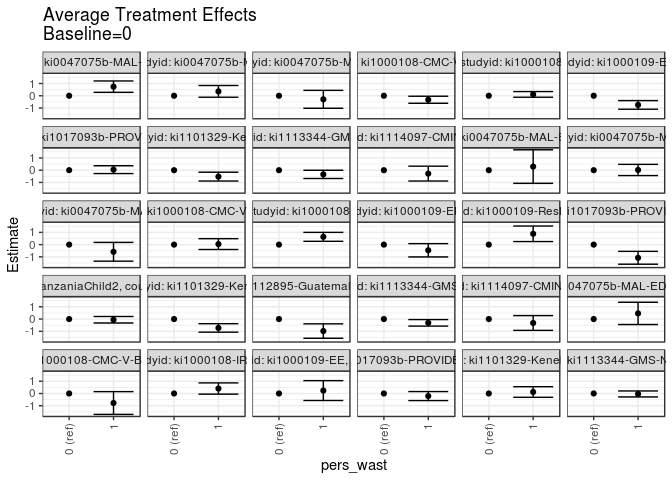

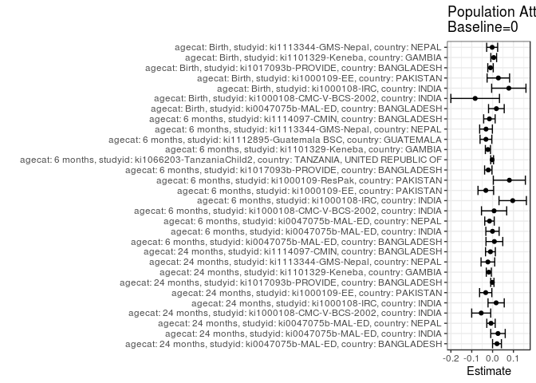

## Results Table

### Parameter: TSM

| agecat | studyid | country | intervention_level | baseline_level | estimate | ci_lower | ci_upper |
| --- | --- | --- | --- | --- | --- | --- | --- |
| Birth | ki0047075b-MAL-ED | BANGLADESH | 0 | NA | -1.1222727 | -1.2564846 | -0.9880609 |
| Birth | ki0047075b-MAL-ED | BANGLADESH | 1 | NA | -0.6600000 | -1.5592093 | 0.2392093 |
| Birth | ki1000108-CMC-V-BCS-2002 | INDIA | 0 | NA | -0.8775955 | -1.0910766 | -0.6641145 |
| Birth | ki1000108-CMC-V-BCS-2002 | INDIA | 1 | NA | -1.6551531 | -2.5575161 | -0.7527901 |
| Birth | ki1000108-IRC | INDIA | 0 | NA | -0.3895182 | -0.5616776 | -0.2173588 |
| Birth | ki1000108-IRC | INDIA | 1 | NA | 0.0155326 | -0.4088608 | 0.4399259 |
| Birth | ki1000109-EE | PAKISTAN | 0 | NA | -1.8884596 | -2.0826032 | -1.6943160 |
| Birth | ki1000109-EE | PAKISTAN | 1 | NA | -1.6496868 | -2.4289364 | -0.8704373 |
| Birth | ki1017093b-PROVIDE | BANGLADESH | 0 | NA | -0.8751550 | -0.9527594 | -0.7975506 |
| Birth | ki1017093b-PROVIDE | BANGLADESH | 1 | NA | -1.0855216 | -1.4451408 | -0.7259024 |
| Birth | ki1101329-Keneba | GAMBIA | 0 | NA | 0.0377955 | -0.0292433 | 0.1048342 |
| Birth | ki1101329-Keneba | GAMBIA | 1 | NA | 0.1599923 | -0.2667936 | 0.5867781 |
| Birth | ki1113344-GMS-Nepal | NEPAL | 0 | NA | -1.0533394 | -1.1453996 | -0.9612792 |
| Birth | ki1113344-GMS-Nepal | NEPAL | 1 | NA | -1.0907026 | -1.3181361 | -0.8632690 |
| 6 months | ki0047075b-MAL-ED | BANGLADESH | 0 | NA | -1.2135826 | -1.3270160 | -1.1001493 |
| 6 months | ki0047075b-MAL-ED | BANGLADESH | 1 | NA | -0.9178571 | -2.2823123 | 0.4465980 |
| 6 months | ki0047075b-MAL-ED | INDIA | 0 | NA | -1.2110180 | -1.3351630 | -1.0868730 |
| 6 months | ki0047075b-MAL-ED | INDIA | 1 | NA | -1.1913671 | -1.6311989 | -0.7515353 |
| 6 months | ki0047075b-MAL-ED | NEPAL | 0 | NA | -0.5467101 | -0.6599035 | -0.4335168 |
| 6 months | ki0047075b-MAL-ED | NEPAL | 1 | NA | -1.1316667 | -1.8892005 | -0.3741328 |
| 6 months | ki1000108-CMC-V-BCS-2002 | INDIA | 0 | NA | -1.4313324 | -1.5845645 | -1.2781003 |
| 6 months | ki1000108-CMC-V-BCS-2002 | INDIA | 1 | NA | -1.3874721 | -1.8014109 | -0.9735332 |
| 6 months | ki1000108-IRC | INDIA | 0 | NA | -1.3347419 | -1.4748150 | -1.1946688 |
| 6 months | ki1000108-IRC | INDIA | 1 | NA | -0.6985786 | -1.0350496 | -0.3621076 |
| 6 months | ki1000109-EE | PAKISTAN | 0 | NA | -2.0510478 | -2.1732899 | -1.9288057 |
| 6 months | ki1000109-EE | PAKISTAN | 1 | NA | -2.5129699 | -3.0427842 | -1.9831556 |
| 6 months | ki1000109-ResPak | PAKISTAN | 0 | NA | -1.4678719 | -1.6880226 | -1.2477213 |
| 6 months | ki1000109-ResPak | PAKISTAN | 1 | NA | -0.5838857 | -1.1781464 | 0.0103750 |
| 6 months | ki1017093b-PROVIDE | BANGLADESH | 0 | NA | -1.0710296 | -1.1457420 | -0.9963172 |
| 6 months | ki1017093b-PROVIDE | BANGLADESH | 1 | NA | -2.1457566 | -2.6641619 | -1.6273514 |
| 6 months | ki1066203-TanzaniaChild2 | TANZANIA, UNITED REPUBLIC OF | 0 | NA | -0.5429630 | -0.5929397 | -0.4929863 |
| 6 months | ki1066203-TanzaniaChild2 | TANZANIA, UNITED REPUBLIC OF | 1 | NA | -0.5991826 | -0.8599404 | -0.3384248 |
| 6 months | ki1101329-Keneba | GAMBIA | 0 | NA | -0.9057713 | -0.9546644 | -0.8568783 |
| 6 months | ki1101329-Keneba | GAMBIA | 1 | NA | -1.6307724 | -1.9745014 | -1.2870435 |
| 6 months | ki1112895-Guatemala BSC | GUATEMALA | 0 | NA | -1.5415418 | -1.6567941 | -1.4262896 |
| 6 months | ki1112895-Guatemala BSC | GUATEMALA | 1 | NA | -2.5211111 | -3.0985428 | -1.9436794 |
| 6 months | ki1113344-GMS-Nepal | NEPAL | 0 | NA | -1.3218376 | -1.4037001 | -1.2399751 |
| 6 months | ki1113344-GMS-Nepal | NEPAL | 1 | NA | -1.6293208 | -1.8824633 | -1.3761782 |
| 6 months | ki1114097-CMIN | BANGLADESH | 0 | NA | -1.7691835 | -1.9106856 | -1.6276814 |
| 6 months | ki1114097-CMIN | BANGLADESH | 1 | NA | -2.0907000 | -2.6770651 | -1.5043349 |
| 24 months | ki0047075b-MAL-ED | BANGLADESH | 0 | NA | -1.9994417 | -2.1279716 | -1.8709119 |
| 24 months | ki0047075b-MAL-ED | BANGLADESH | 1 | NA | -1.2558333 | -1.7012482 | -0.8104185 |
| 24 months | ki0047075b-MAL-ED | INDIA | 0 | NA | -1.9120506 | -2.0434196 | -1.7806816 |
| 24 months | ki0047075b-MAL-ED | INDIA | 1 | NA | -1.5542641 | -2.0157511 | -1.0927771 |
| 24 months | ki0047075b-MAL-ED | NEPAL | 0 | NA | -1.2999550 | -1.4209558 | -1.1789541 |
| 24 months | ki0047075b-MAL-ED | NEPAL | 1 | NA | -1.5900000 | -2.3102086 | -0.8697914 |
| 24 months | ki1000108-CMC-V-BCS-2002 | INDIA | 0 | NA | -2.4943169 | -2.5992071 | -2.3894267 |
| 24 months | ki1000108-CMC-V-BCS-2002 | INDIA | 1 | NA | -2.8203821 | -3.0869922 | -2.5537719 |
| 24 months | ki1000108-IRC | INDIA | 0 | NA | -1.8159424 | -1.9212027 | -1.7106821 |
| 24 months | ki1000108-IRC | INDIA | 1 | NA | -1.7042585 | -1.9111162 | -1.4974007 |
| 24 months | ki1000109-EE | PAKISTAN | 0 | NA | -2.6369227 | -2.7879668 | -2.4858786 |
| 24 months | ki1000109-EE | PAKISTAN | 1 | NA | -3.3847201 | -3.7027559 | -3.0666844 |
| 24 months | ki1017093b-PROVIDE | BANGLADESH | 0 | NA | -1.6013891 | -1.6864992 | -1.5162789 |
| 24 months | ki1017093b-PROVIDE | BANGLADESH | 1 | NA | -1.5572867 | -1.8651580 | -1.2494155 |
| 24 months | ki1101329-Keneba | GAMBIA | 0 | NA | -1.5743285 | -1.6285873 | -1.5200698 |
| 24 months | ki1101329-Keneba | GAMBIA | 1 | NA | -2.0995173 | -2.4560662 | -1.7429683 |
| 24 months | ki1113344-GMS-Nepal | NEPAL | 0 | NA | -1.8712472 | -1.9602031 | -1.7822912 |
| 24 months | ki1113344-GMS-Nepal | NEPAL | 1 | NA | -2.2133498 | -2.5360898 | -1.8906098 |
| 24 months | ki1114097-CMIN | BANGLADESH | 0 | NA | -2.5005794 | -2.6283894 | -2.3727694 |
| 24 months | ki1114097-CMIN | BANGLADESH | 1 | NA | -2.7794444 | -3.3734067 | -2.1854822 |

### Parameter: E(Y)

| agecat | studyid | country | intervention_level | baseline_level | estimate | ci_lower | ci_upper |
| --- | --- | --- | --- | --- | --- | --- | --- |
| Birth | ki0047075b-MAL-ED | BANGLADESH | NA | NA | -1.1041048 | -1.2383048 | -0.9699048 |
| Birth | ki1000108-CMC-V-BCS-2002 | INDIA | NA | NA | -0.9611957 | -1.1776967 | -0.7446946 |
| Birth | ki1000108-IRC | INDIA | NA | NA | -0.3117313 | -0.4727359 | -0.1507267 |
| Birth | ki1000109-EE | PAKISTAN | NA | NA | -1.8608750 | -2.0482045 | -1.6735455 |
| Birth | ki1017093b-PROVIDE | BANGLADESH | NA | NA | -0.8851020 | -0.9601332 | -0.8100709 |
| Birth | ki1101329-Keneba | GAMBIA | NA | NA | 0.0432135 | -0.0229516 | 0.1093787 |
| Birth | ki1113344-GMS-Nepal | NEPAL | NA | NA | -1.0554530 | -1.1411259 | -0.9697801 |
| 6 months | ki0047075b-MAL-ED | BANGLADESH | NA | NA | -1.2049931 | -1.3222136 | -1.0877726 |
| 6 months | ki0047075b-MAL-ED | INDIA | NA | NA | -1.2115254 | -1.3298727 | -1.0931782 |
| 6 months | ki0047075b-MAL-ED | NEPAL | NA | NA | -0.5615819 | -0.6741832 | -0.4489807 |
| 6 months | ki1000108-CMC-V-BCS-2002 | INDIA | NA | NA | -1.4241872 | -1.5668135 | -1.2815609 |
| 6 months | ki1000108-IRC | INDIA | NA | NA | -1.2382964 | -1.3698449 | -1.1067479 |
| 6 months | ki1000109-EE | PAKISTAN | NA | NA | -2.0835567 | -2.2027557 | -1.9643578 |
| 6 months | ki1000109-ResPak | PAKISTAN | NA | NA | -1.3874523 | -1.5959323 | -1.1789723 |
| 6 months | ki1017093b-PROVIDE | BANGLADESH | NA | NA | -1.0916915 | -1.1661176 | -1.0172654 |
| 6 months | ki1066203-TanzaniaChild2 | TANZANIA, UNITED REPUBLIC OF | NA | NA | -0.5450830 | -0.5941754 | -0.4959906 |
| 6 months | ki1101329-Keneba | GAMBIA | NA | NA | -0.9282048 | -0.9770928 | -0.8793169 |
| 6 months | ki1112895-Guatemala BSC | GUATEMALA | NA | NA | -1.5734843 | -1.6884116 | -1.4585570 |
| 6 months | ki1113344-GMS-Nepal | NEPAL | NA | NA | -1.3533244 | -1.4319426 | -1.2747062 |
| 6 months | ki1114097-CMIN | BANGLADESH | NA | NA | -1.7844376 | -1.9222926 | -1.6465825 |
| 24 months | ki0047075b-MAL-ED | BANGLADESH | NA | NA | -1.9783962 | -2.1050210 | -1.8517715 |
| 24 months | ki0047075b-MAL-ED | INDIA | NA | NA | -1.8861894 | -2.0110006 | -1.7613783 |
| 24 months | ki0047075b-MAL-ED | NEPAL | NA | NA | -1.3075877 | -1.4270718 | -1.1881037 |
| 24 months | ki1000108-CMC-V-BCS-2002 | INDIA | NA | NA | -2.5489071 | -2.6476125 | -2.4502017 |
| 24 months | ki1000108-IRC | INDIA | NA | NA | -1.7989338 | -1.8927769 | -1.7050907 |
| 24 months | ki1000109-EE | PAKISTAN | NA | NA | -2.6699900 | -2.8138051 | -2.5261749 |
| 24 months | ki1017093b-PROVIDE | BANGLADESH | NA | NA | -1.6024221 | -1.6857420 | -1.5191023 |
| 24 months | ki1101329-Keneba | GAMBIA | NA | NA | -1.5924094 | -1.6461889 | -1.5386298 |
| 24 months | ki1113344-GMS-Nepal | NEPAL | NA | NA | -1.8938622 | -1.9795205 | -1.8082040 |
| 24 months | ki1114097-CMIN | BANGLADESH | NA | NA | -2.5109504 | -2.6361514 | -2.3857494 |

### Parameter: ATE

| agecat | studyid | country | intervention_level | baseline_level | estimate | ci_lower | ci_upper |
| --- | --- | --- | --- | --- | --- | --- | --- |
| Birth | ki0047075b-MAL-ED | BANGLADESH | 0 | 0 | 0.0000000 | 0.0000000 | 0.0000000 |
| Birth | ki0047075b-MAL-ED | BANGLADESH | 1 | 0 | 0.4622727 | -0.4468973 | 1.3714428 |
| Birth | ki1000108-CMC-V-BCS-2002 | INDIA | 0 | 0 | 0.0000000 | 0.0000000 | 0.0000000 |
| Birth | ki1000108-CMC-V-BCS-2002 | INDIA | 1 | 0 | -0.7775576 | -1.7077722 | 0.1526570 |
| Birth | ki1000108-IRC | INDIA | 0 | 0 | 0.0000000 | 0.0000000 | 0.0000000 |
| Birth | ki1000108-IRC | INDIA | 1 | 0 | 0.4050508 | -0.0528816 | 0.8629832 |
| Birth | ki1000109-EE | PAKISTAN | 0 | 0 | 0.0000000 | 0.0000000 | 0.0000000 |
| Birth | ki1000109-EE | PAKISTAN | 1 | 0 | 0.2387728 | -0.5713997 | 1.0489453 |
| Birth | ki1017093b-PROVIDE | BANGLADESH | 0 | 0 | 0.0000000 | 0.0000000 | 0.0000000 |
| Birth | ki1017093b-PROVIDE | BANGLADESH | 1 | 0 | -0.2103667 | -0.5777495 | 0.1570162 |
| Birth | ki1101329-Keneba | GAMBIA | 0 | 0 | 0.0000000 | 0.0000000 | 0.0000000 |
| Birth | ki1101329-Keneba | GAMBIA | 1 | 0 | 0.1221968 | -0.3099628 | 0.5543563 |
| Birth | ki1113344-GMS-Nepal | NEPAL | 0 | 0 | 0.0000000 | 0.0000000 | 0.0000000 |
| Birth | ki1113344-GMS-Nepal | NEPAL | 1 | 0 | -0.0373632 | -0.2821620 | 0.2074356 |
| 6 months | ki0047075b-MAL-ED | BANGLADESH | 0 | 0 | 0.0000000 | 0.0000000 | 0.0000000 |
| 6 months | ki0047075b-MAL-ED | BANGLADESH | 1 | 0 | 0.2957255 | -1.0734367 | 1.6648877 |
| 6 months | ki0047075b-MAL-ED | INDIA | 0 | 0 | 0.0000000 | 0.0000000 | 0.0000000 |
| 6 months | ki0047075b-MAL-ED | INDIA | 1 | 0 | 0.0196509 | -0.4376842 | 0.4769861 |
| 6 months | ki0047075b-MAL-ED | NEPAL | 0 | 0 | 0.0000000 | 0.0000000 | 0.0000000 |
| 6 months | ki0047075b-MAL-ED | NEPAL | 1 | 0 | -0.5849565 | -1.3509005 | 0.1809875 |
| 6 months | ki1000108-CMC-V-BCS-2002 | INDIA | 0 | 0 | 0.0000000 | 0.0000000 | 0.0000000 |
| 6 months | ki1000108-CMC-V-BCS-2002 | INDIA | 1 | 0 | 0.0438603 | -0.3984014 | 0.4861220 |
| 6 months | ki1000108-IRC | INDIA | 0 | 0 | 0.0000000 | 0.0000000 | 0.0000000 |
| 6 months | ki1000108-IRC | INDIA | 1 | 0 | 0.6361633 | 0.2712316 | 1.0010950 |
| 6 months | ki1000109-EE | PAKISTAN | 0 | 0 | 0.0000000 | 0.0000000 | 0.0000000 |
| 6 months | ki1000109-EE | PAKISTAN | 1 | 0 | -0.4619221 | -1.0057710 | 0.0819267 |
| 6 months | ki1000109-ResPak | PAKISTAN | 0 | 0 | 0.0000000 | 0.0000000 | 0.0000000 |
| 6 months | ki1000109-ResPak | PAKISTAN | 1 | 0 | 0.8839862 | 0.2496714 | 1.5183011 |
| 6 months | ki1017093b-PROVIDE | BANGLADESH | 0 | 0 | 0.0000000 | 0.0000000 | 0.0000000 |
| 6 months | ki1017093b-PROVIDE | BANGLADESH | 1 | 0 | -1.0747270 | -1.5980213 | -0.5514327 |
| 6 months | ki1066203-TanzaniaChild2 | TANZANIA, UNITED REPUBLIC OF | 0 | 0 | 0.0000000 | 0.0000000 | 0.0000000 |
| 6 months | ki1066203-TanzaniaChild2 | TANZANIA, UNITED REPUBLIC OF | 1 | 0 | -0.0562197 | -0.3214967 | 0.2090573 |
| 6 months | ki1101329-Keneba | GAMBIA | 0 | 0 | 0.0000000 | 0.0000000 | 0.0000000 |
| 6 months | ki1101329-Keneba | GAMBIA | 1 | 0 | -0.7250011 | -1.0722523 | -0.3777499 |
| 6 months | ki1112895-Guatemala BSC | GUATEMALA | 0 | 0 | 0.0000000 | 0.0000000 | 0.0000000 |
| 6 months | ki1112895-Guatemala BSC | GUATEMALA | 1 | 0 | -0.9795693 | -1.5683905 | -0.3907481 |
| 6 months | ki1113344-GMS-Nepal | NEPAL | 0 | 0 | 0.0000000 | 0.0000000 | 0.0000000 |
| 6 months | ki1113344-GMS-Nepal | NEPAL | 1 | 0 | -0.3074831 | -0.5734647 | -0.0415016 |
| 6 months | ki1114097-CMIN | BANGLADESH | 0 | 0 | 0.0000000 | 0.0000000 | 0.0000000 |
| 6 months | ki1114097-CMIN | BANGLADESH | 1 | 0 | -0.3215165 | -0.9244020 | 0.2813690 |
| 24 months | ki0047075b-MAL-ED | BANGLADESH | 0 | 0 | 0.0000000 | 0.0000000 | 0.0000000 |
| 24 months | ki0047075b-MAL-ED | BANGLADESH | 1 | 0 | 0.7436084 | 0.2800199 | 1.2071969 |
| 24 months | ki0047075b-MAL-ED | INDIA | 0 | 0 | 0.0000000 | 0.0000000 | 0.0000000 |
| 24 months | ki0047075b-MAL-ED | INDIA | 1 | 0 | 0.3577865 | -0.1215226 | 0.8370956 |
| 24 months | ki0047075b-MAL-ED | NEPAL | 0 | 0 | 0.0000000 | 0.0000000 | 0.0000000 |
| 24 months | ki0047075b-MAL-ED | NEPAL | 1 | 0 | -0.2900450 | -1.0203475 | 0.4402574 |
| 24 months | ki1000108-CMC-V-BCS-2002 | INDIA | 0 | 0 | 0.0000000 | 0.0000000 | 0.0000000 |
| 24 months | ki1000108-CMC-V-BCS-2002 | INDIA | 1 | 0 | -0.3260651 | -0.6132700 | -0.0388602 |
| 24 months | ki1000108-IRC | INDIA | 0 | 0 | 0.0000000 | 0.0000000 | 0.0000000 |
| 24 months | ki1000108-IRC | INDIA | 1 | 0 | 0.1116839 | -0.1204536 | 0.3438215 |
| 24 months | ki1000109-EE | PAKISTAN | 0 | 0 | 0.0000000 | 0.0000000 | 0.0000000 |
| 24 months | ki1000109-EE | PAKISTAN | 1 | 0 | -0.7477974 | -1.1001277 | -0.3954672 |
| 24 months | ki1017093b-PROVIDE | BANGLADESH | 0 | 0 | 0.0000000 | 0.0000000 | 0.0000000 |
| 24 months | ki1017093b-PROVIDE | BANGLADESH | 1 | 0 | 0.0441023 | -0.2753337 | 0.3635383 |
| 24 months | ki1101329-Keneba | GAMBIA | 0 | 0 | 0.0000000 | 0.0000000 | 0.0000000 |
| 24 months | ki1101329-Keneba | GAMBIA | 1 | 0 | -0.5251887 | -0.8861595 | -0.1642180 |
| 24 months | ki1113344-GMS-Nepal | NEPAL | 0 | 0 | 0.0000000 | 0.0000000 | 0.0000000 |
| 24 months | ki1113344-GMS-Nepal | NEPAL | 1 | 0 | -0.3421027 | -0.6773017 | -0.0069036 |
| 24 months | ki1114097-CMIN | BANGLADESH | 0 | 0 | 0.0000000 | 0.0000000 | 0.0000000 |
| 24 months | ki1114097-CMIN | BANGLADESH | 1 | 0 | -0.2788650 | -0.8864229 | 0.3286928 |

### Parameter: PAR

| agecat | studyid | country | intervention_level | baseline_level | estimate | ci_lower | ci_upper |
| --- | --- | --- | --- | --- | --- | --- | --- |
| Birth | ki0047075b-MAL-ED | BANGLADESH | 0 | NA | 0.0181679 | -0.0194178 | 0.0557537 |
| Birth | ki1000108-CMC-V-BCS-2002 | INDIA | 0 | NA | -0.0836001 | -0.2001321 | 0.0329319 |
| Birth | ki1000108-IRC | INDIA | 0 | NA | 0.0777870 | -0.0045318 | 0.1601058 |
| Birth | ki1000109-EE | PAKISTAN | 0 | NA | 0.0275846 | -0.0263419 | 0.0815111 |
| Birth | ki1017093b-PROVIDE | BANGLADESH | 0 | NA | -0.0099471 | -0.0230503 | 0.0031561 |
| Birth | ki1101329-Keneba | GAMBIA | 0 | NA | 0.0054180 | -0.0084004 | 0.0192365 |
| Birth | ki1113344-GMS-Nepal | NEPAL | 0 | NA | -0.0021136 | -0.0284363 | 0.0242091 |
| 6 months | ki0047075b-MAL-ED | BANGLADESH | 0 | NA | 0.0085895 | -0.0316719 | 0.0488510 |
| 6 months | ki0047075b-MAL-ED | INDIA | 0 | NA | -0.0005074 | -0.0323419 | 0.0313270 |
| 6 months | ki0047075b-MAL-ED | NEPAL | 0 | NA | -0.0148718 | -0.0376268 | 0.0078833 |
| 6 months | ki1000108-CMC-V-BCS-2002 | INDIA | 0 | NA | 0.0071451 | -0.0533471 | 0.0676374 |
| 6 months | ki1000108-IRC | INDIA | 0 | NA | 0.0964455 | 0.0307582 | 0.1621328 |
| 6 months | ki1000109-EE | PAKISTAN | 0 | NA | -0.0325090 | -0.0699478 | 0.0049299 |
| 6 months | ki1000109-ResPak | PAKISTAN | 0 | NA | 0.0804197 | 0.0035872 | 0.1572521 |
| 6 months | ki1017093b-PROVIDE | BANGLADESH | 0 | NA | -0.0206619 | -0.0383054 | -0.0030184 |
| 6 months | ki1066203-TanzaniaChild2 | TANZANIA, UNITED REPUBLIC OF | 0 | NA | -0.0021200 | -0.0087876 | 0.0045476 |
| 6 months | ki1101329-Keneba | GAMBIA | 0 | NA | -0.0224335 | -0.0346552 | -0.0102117 |
| 6 months | ki1112895-Guatemala BSC | GUATEMALA | 0 | NA | -0.0319425 | -0.0600761 | -0.0038089 |
| 6 months | ki1113344-GMS-Nepal | NEPAL | 0 | NA | -0.0314868 | -0.0619987 | -0.0009749 |
| 6 months | ki1114097-CMIN | BANGLADESH | 0 | NA | -0.0152541 | -0.0427830 | 0.0122748 |
| 24 months | ki0047075b-MAL-ED | BANGLADESH | 0 | NA | 0.0210455 | -0.0001441 | 0.0422351 |
| 24 months | ki0047075b-MAL-ED | INDIA | 0 | NA | 0.0258612 | -0.0088429 | 0.0605653 |
| 24 months | ki0047075b-MAL-ED | NEPAL | 0 | NA | -0.0076328 | -0.0277780 | 0.0125124 |
| 24 months | ki1000108-CMC-V-BCS-2002 | INDIA | 0 | NA | -0.0545902 | -0.1001624 | -0.0090179 |
| 24 months | ki1000108-IRC | INDIA | 0 | NA | 0.0170086 | -0.0218730 | 0.0558901 |
| 24 months | ki1000109-EE | PAKISTAN | 0 | NA | -0.0330673 | -0.0624206 | -0.0037140 |
| 24 months | ki1017093b-PROVIDE | BANGLADESH | 0 | NA | -0.0010331 | -0.0088169 | 0.0067508 |
| 24 months | ki1101329-Keneba | GAMBIA | 0 | NA | -0.0180809 | -0.0302413 | -0.0059204 |
| 24 months | ki1113344-GMS-Nepal | NEPAL | 0 | NA | -0.0226151 | -0.0554227 | 0.0101926 |
| 24 months | ki1114097-CMIN | BANGLADESH | 0 | NA | -0.0103710 | -0.0339279 | 0.0131858 |